# Lattice Plotting System

Mr. Sachin B.

### 1. Lattice Plotting System

- The lattice plotting system is completely separate and independent of the base plotting system.
- It has to be explicitly loaded with a call to the R function library.
- Lattice "is an implementation of Trellis graphics for R.
- It is a powerful and elegant high-level data visualization system with an emphasis on multivariate data.

#### 1.1. Lattice is implemented using two packages.

1. The first is called `lattice`
   - It contains code for producing Trellis graphics.
   - Some of the functions in this package are the higher level functions which the user would call.
   - These include `xyplot`, `bwplot`, and `levelplot`.
2. The second package in the lattice system is `grid`
   - which contains the low-level functions upon which the lattice package is built.
   - The user seldom call functions from the grid package directly.

#### 1.2. Compare and Contrast to Base Plotting System

- Unlike base plotting, the lattice system does not have a “two-phase” aspect with separate plotting and annotation.
  - Instead all plotting and annotation is done at once with a single function call.
- The lattice system, as the base does, provides several different plotting functions.
  - These include
    - `xyplot` for creating scatterplots,
    - `bwplot` for box-and-whiskers plots or boxplots, and
    - `histogram` for histograms.
  - There are several others such as `stripplot`, `dotplot`, `splom` and `levelplot`

### 2. Lattice functions

- Lattice functions generally take a formula for their first argument, usually of the form **y ~ x**.
  - This indicates that y depends on x, so in a scatterplot y would be plotted on the y-axis and x on the x-axis.
- Example: **xyplot(y ~ x | f * g, data)**
  1. The first argument is the condition
     - The f and g represent the optional conditioning variables.
     - The * represents interaction between them.
  2. The second argument is the data frame or list from which the variables in the formula should be looked up.
     - If no data frame or list is passed, then the parent frame is used.
     - If no other arguments are passed, the default values are used.

#### 2.1. xyplot() without annotation

```r
#Load Lattice Plot
library(lattice)

# To see data
airquality<-read.csv("./data/airquality.csv")
head(airquality)
```

```
##   X Ozone Solar.R Wind Temp Month Day
## 1 1    41     190  7.4   67     5   1
## 2 2    36     118  8.0   72     5   2
## 3 3    12     149 12.6   74     5   3
## 4 4    18     313 11.5   62     5   4
## 5 5    NA      NA 14.3   56     5   5
## 6 6    28      NA 14.9   66     5   6
```

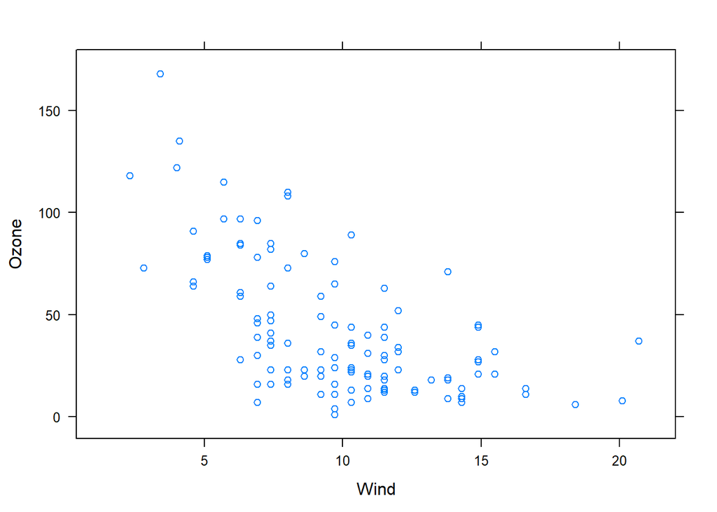

```r
# xyplot
xyplot(Ozone~Wind,airquality)
```

#### 2.2. xyplot() with annotation

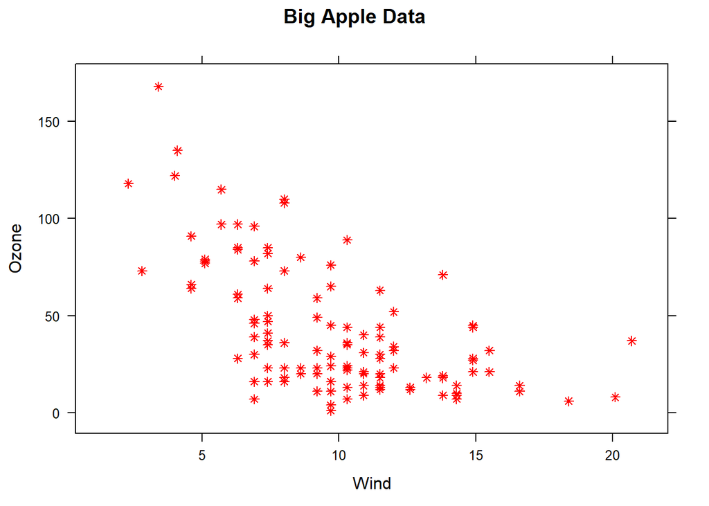

```r
# xyplot
xyplot(Ozone ~ Wind, data = airquality, pch=8, col="red",main="Big Apple Data")
```

### 3. Multipanel Plot

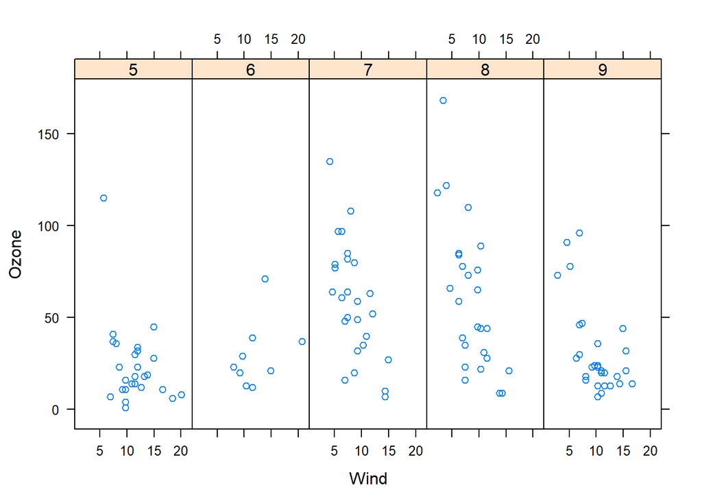

```r
# xyplot
xyplot(Ozone ~ Wind | as.factor(Month), data = airquality,layout=c(5,1))
```

- **as.factor(Month)** Displayed and labeled each subplot with the month’s integer

### 4. Trellis Plot Object

```r
# returns a trellis plot object which stored in p
# plot will not be printed
p <- xyplot(Ozone~Wind,airquality)
```

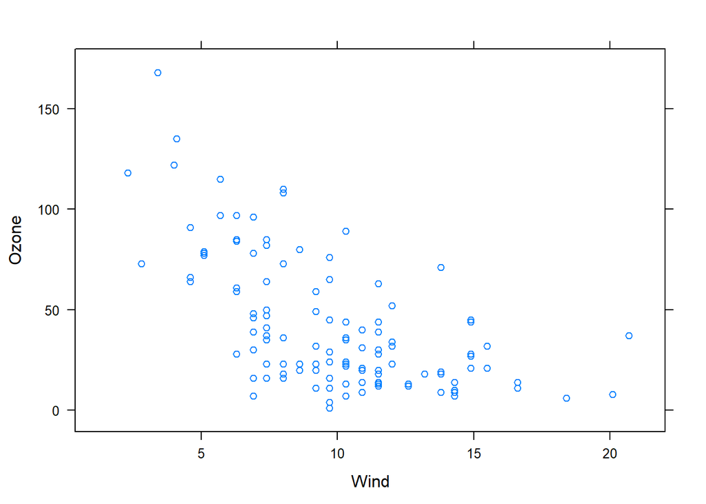

```r
# print 'p' to print plot
print(p)
```

#### The trellis object p has 45 named properties

```r
names(p)
```

```
##  [1] "formula"           "as.table"          "aspect.fill"
##  [4] "legend"            "panel"             "page"
##  [7] "layout"            "skip"              "strip"
## [10] "strip.left"        "xscale.components" "yscale.components"
## [13] "axis"              "xlab"              "ylab"
## [16] "xlab.default"      "ylab.default"      "xlab.top"
## [19] "ylab.right"        "main"              "sub"
## [22] "x.between"         "y.between"         "par.settings"
## [25] "plot.args"         "lattice.options"   "par.strip.text"
## [28] "index.cond"        "perm.cond"         "condlevels"
## [31] "call"              "x.scales"          "y.scales"
## [34] "panel.args.common" "panel.args"        "packet.sizes"
## [37] "x.limits"          "y.limits"          "x.used.at"
## [40] "y.used.at"         "x.num.limit"       "y.num.limit"
## [43] "aspect.ratio"      "prepanel.default"  "prepanel"
```

#### Out of 45 Which properties has values

```r
# creating vector of all properties names
mynames<-names(p)

# creating boolean vector, myfull, which has TRUE values for non-null entries of p.

is.not.null <- function(x) !is.null(x)
myful= sapply(p, is.not.null)
for(i in mynames)
{
  myfull <- paste0(myful)
}
myfull=as.logical(myfull)

# printing properties which has non- null values
mynames[myfull]
```

```
##  [1] "formula"           "as.table"          "aspect.fill"
##  [4] "panel"             "skip"              "strip"
##  [7] "strip.left"        "xscale.components" "yscale.components"
## [10] "axis"              "xlab"              "ylab"
## [13] "xlab.default"      "ylab.default"      "x.between"
## [16] "y.between"         "index.cond"        "perm.cond"
## [19] "condlevels"        "call"              "x.scales"
## [22] "y.scales"          "panel.args.common" "panel.args"
## [25] "packet.sizes"      "x.limits"          "y.limits"
## [28] "aspect.ratio"      "prepanel.default"
```

```r
# print the values for some non-null properties
## 1.
p[["formula"]]
```

```
## Ozone ~ Wind
```

```r
## 2.
p[["x.limits"]]
```

```
## [1]  0.37 22.03
```

### 5. panel functions

The lattice package comes with default panel functions, but you can customize what happens in each panel.

#### Creating data

```r
# creating data for x,y and z
# x has 100 random values
x<- rnorm(100)

#  first 50 values of y is a function of x and last 50 values are random.
y<- rnorm(50)+ x[1:50]
y[51:100] <- rnorm(50)

# 100-long factor vector f which distinguishes between the first and last 50 elements of the two vectors.

f<- gl(2,50,labels = c("Group 1","Group 2"))

table((f))
```

```
##
## Group 1 Group 2
##      50      50
```

#### xyplot()

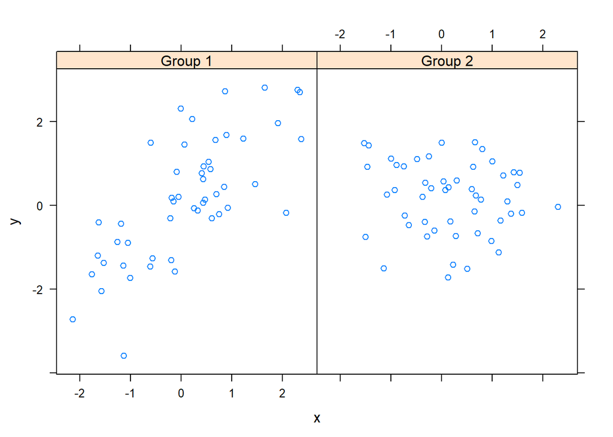

```r
xyplot(y~x|f,layout=c(2,1))
```

#### Ranges of x and y values

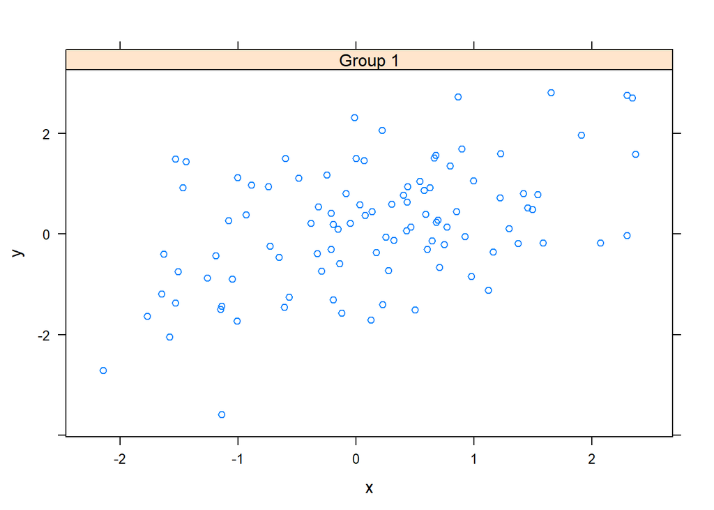

```r
a<-xyplot(y~x|levels(f)[1])
a
```

```r
V1 <- c(range(x[f==levels(f)[1]]),range(y[f==levels(f)[1]]))

names(V1)<- c("x_min_Group_1","x_max_Group_1","y_min_Group_1","y_max_Group_1")
V1
```

```
## x_min_Group_1 x_max_Group_1 y_min_Group_1 y_max_Group_1
##     -2.142064      2.370144     -3.584890      2.816101
```

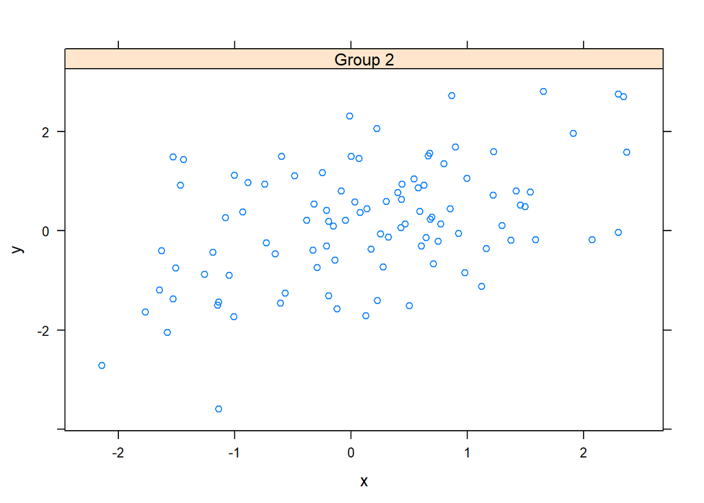

```r
b<-xyplot(y~x|levels(f)[2])
b
```

```r
V2 <- c(range(x[f==levels(f)[2]]),range(y[f==levels(f)[2]]))

names(V2)<- c("x_min_Group_2","x_max_Group_2","y_min_Group_2","y_max_Group_2")
V2
```

```
## x_min_Group_2 x_max_Group_2 y_min_Group_2 y_max_Group_2
##     -1.530674      2.295970     -1.710228      1.512670
```

### 6. lattice’s panel plotting capability

#### Getting ‘diamonds’ dataset

```r
# 'diamonds' dataset is built-in available in ggplot2 package
library(ggplot2)
head(diamonds)
```

```
## # A tibble: 6 x 10
##   carat cut       color clarity depth table price     x     y     z
##   <dbl> <ord>     <ord> <ord>   <dbl> <dbl> <int> <dbl> <dbl> <dbl>
## 1 0.23  Ideal     E     SI2      61.5    55   326  3.95  3.98  2.43
## 2 0.21  Premium   E     SI1      59.8    61   326  3.89  3.84  2.31
## 3 0.23  Good      E     VS1      56.9    65   327  4.05  4.07  2.31
## 4 0.290 Premium   I     VS2      62.4    58   334  4.2   4.23  2.63
## 5 0.31  Good      J     SI2      63.3    58   335  4.34  4.35  2.75
## 6 0.24  Very Good J     VVS2     62.8    57   336  3.94  3.96  2.48
```

```r
#structure of diamonds dataset
str(diamonds)
```

```
## tibble [53,940 x 10] (S3: tbl_df/tbl/data.frame)
##  $ carat  : num [1:53940] 0.23 0.21 0.23 0.29 0.31 0.24 0.24 0.26 0.22 0.23 ...
##  $ cut    : Ord.factor w/ 5 levels "Fair"<"Good"<..: 5 4 2 4 2 3 3 3 1 3 ...
##  $ color  : Ord.factor w/ 7 levels "D"<"E"<"F"<"G"<..: 2 2 2 6 7 7 6 5 2 5 ...
##  $ clarity: Ord.factor w/ 8 levels "I1"<"SI2"<"SI1"<..: 2 3 5 4 2 6 7 3 4 5 ...
##  $ depth  : num [1:53940] 61.5 59.8 56.9 62.4 63.3 62.8 62.3 61.9 65.1 59.4 ...
##  $ table  : num [1:53940] 55 61 65 58 58 57 57 55 61 61 ...
##  $ price  : int [1:53940] 326 326 327 334 335 336 336 337 337 338 ...
##  $ x      : num [1:53940] 3.95 3.89 4.05 4.2 4.34 3.94 3.95 4.07 3.87 4 ...
##  $ y      : num [1:53940] 3.98 3.84 4.07 4.23 4.35 3.96 3.98 4.11 3.78 4.05 ...
##  $ z      : num [1:53940] 2.43 2.31 2.31 2.63 2.75 2.48 2.47 2.53 2.49 2.39 ...
```

```r
# 20 sample values of color column
sample(diamonds$color,20)
```

```
##  [1] E F H D F D I G I F G E D H F D E H H G
## Levels: D < E < F < G < H < I < J
```

```r
# No. of values for each color of diamonds
table(diamonds$color)
```

```
##
##     D     E     F     G     H     I     J
##  6775  9797  9542 11292  8304  5422  2808
```

```r
# diamonds color Vs diamonds cut
table(diamonds$color,diamonds$cut)
```

```
##
##     Fair Good Very Good Premium Ideal
##   D  163  662      1513    1603  2834
##   E  224  933      2400    2337  3903
##   F  312  909      2164    2331  3826
##   G  314  871      2299    2924  4884
##   H  303  702      1824    2360  3115
##   I  175  522      1204    1428  2093
##   J  119  307       678     808   896
```

#### xyplot for price and carat according to color and cut in panels

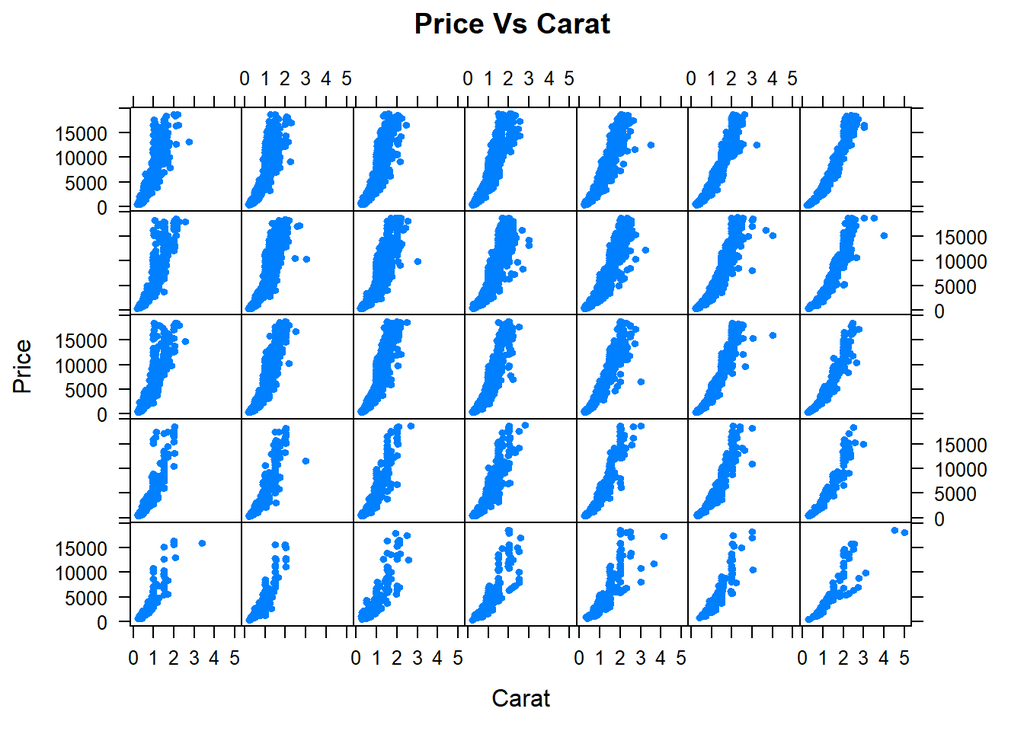

```r
xyplot(price~carat | color*cut,data = diamonds,strip = FALSE, pch = 20, xlab = "Carat", ylab ="Price",main= "Price Vs Carat")
```

Q: color*cut which column appear on x-axis? A: There are 5 rows and 7 columns similar to 5 cuts and 7 colors therefor ‘color’ column is on x-axis.

Q: What does `strip=FALSE` do? A: strip argument shows labels information of each panel

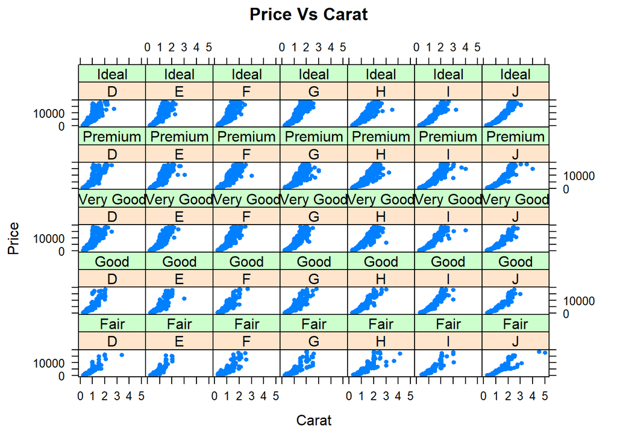

```r
xyplot(price~carat | color*cut,data = diamonds,strip = TRUE, pch = 20, xlab = "Carat", ylab ="Price",main= "Price Vs Carat")
```